# Classification Prediction

Gustavo Monteiro

November 18, 2018

> The database that will be used in this study consists of data on the votes that candidates for the Federal Chamber of Deputies received in the years 2006 and 2010 (source: http://www.tse.jus.br), as well as information on campaigning, party, schooling, … of them.

## Loading data.

```r
set.seed(1)

data <- read.csv("train.csv")
data$id <- 1:nrow(data)

data %>%
  sample_frac(.9) -> train

test <- read.csv("test.csv")
anti_join(data, train, by = 'id') -> validation
```

> Let’s explore the data features

```r
train %>%
  glimpse()
```

```
## Observations: 6,860
## Variables: 25
## $ ano                                   <int> 2006, 2006, 2010, 2010, ...
## $ sequencial_candidato                  <dbl> 1.0590e+04, 1.1295e+04, ...
## $ nome                                  <fct> PAULO DUARTE, ANTÔNIO MA...
## $ uf                                    <fct> PR, MG, MA, SP, MG, SP, ...
## $ partido                               <fct> PSDC, PSC, PC do B, PTN,...
## $ quantidade_doacoes                    <int> 1, 3, 5, 3, 1, 27, 23, 4...
## $ quantidade_doadores                   <int> 1, 3, 5, 3, 1, 24, 17, 4...
## $ total_receita                         <dbl> 305.90, 3670.00, 13030.0...
## $ media_receita                         <dbl> 305.90, 1223.33, 2606.00...
## $ recursos_de_outros_candidatos.comites <dbl> 305.90, 2340.00, 0.00, 0...
## $ recursos_de_pessoas_fisicas           <dbl> 0.0, 1330.0, 1700.0, 100...
## $ recursos_de_pessoas_juridicas         <dbl> 0.00, 0.00, 11330.00, 0....
## $ recursos_proprios                     <dbl> 0.00, 0.00, 0.00, 0.00, ...
## $ recursos_de_partido_politico          <dbl> 0.0, 0.0, 0.0, 354.5, 0....
## $ quantidade_despesas                   <int> 1, 3, 7, 3, 1, 75, 22, 2...
## $ quantidade_fornecedores               <int> 1, 3, 6, 3, 1, 69, 22, 1...
## $ total_despesa                         <dbl> 305.90, 3670.00, 12230.0...
## $ media_despesa                         <dbl> 305.90, 1223.33, 1747.14...
## $ cargo                                 <fct> DEPUTADO FEDERAL, DEPUTA...
## $ sexo                                  <fct> MASCULINO, MASCULINO, MA...
## $ grau                                  <fct> SUPERIOR INCOMPLETO, SUP...
## $ estado_civil                          <fct> CASADO(A), DIVORCIADO(A)...
## $ ocupacao                              <fct> EMPRESÁRIO, ESTUDANTE, B...
## $ situacao                              <fct> nao_eleito, nao_eleito, ...
## $ id                                    <int> 2024, 2836, 4366, 6920, ...
```

> following, we will explore classes balance of data attributes, that is an important point to prevent overfiting in prediction models.

Feature by feature, we will show balance by target variable, which in this study is `situaçao`, whether a deputy was elected or not, and comment if the class is umbalanced

### recursos_proprios

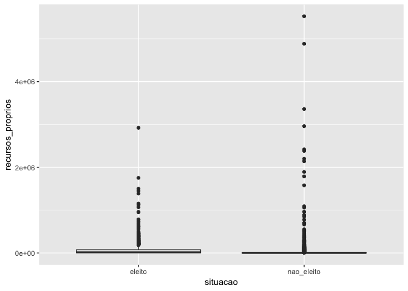

```r
train %>%
  ggplot(aes(situacao,recursos_proprios)) +
  geom_boxplot()
```

unbalanced, high ranges recourse is more common in non-elected

### recursos_de_partido_politico

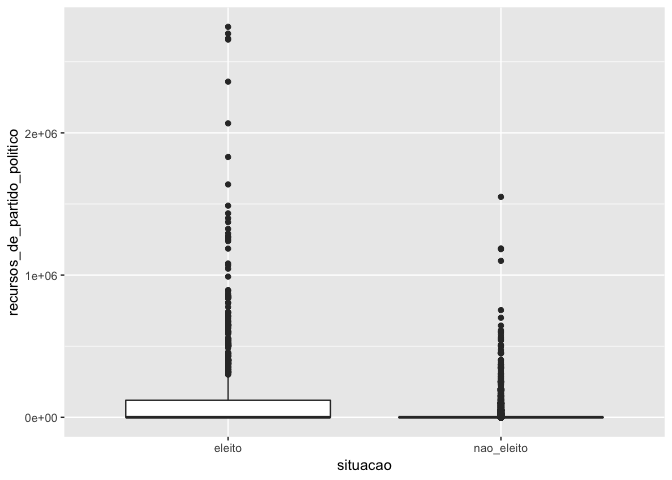

```r
train %>%
  ggplot(aes(situacao,
             recursos_de_partido_politico)) +
  geom_boxplot()
```

unbalanced, high ranges recourse is more common in elected

### recursos_de_outros_candidatos.comites

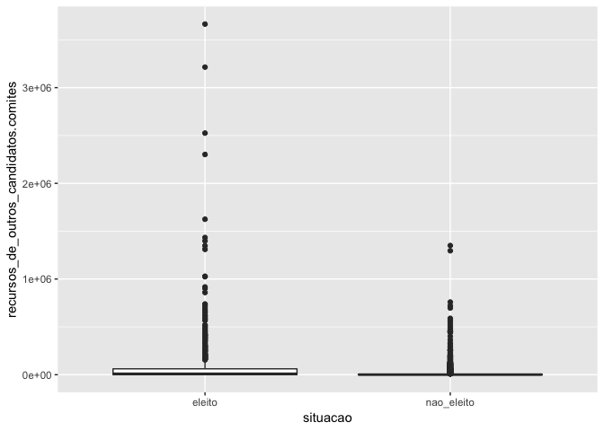

```r
train %>%
  ggplot(aes(situacao,
             recursos_de_outros_candidatos.comites)) +
  geom_boxplot()
```

the same situation of `recursos_de_partido_politico`

### recursos_de_pessoas_fisicas

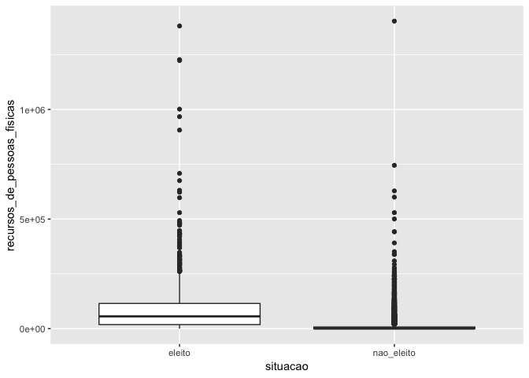

```r
train %>%
  ggplot(aes(situacao,
             recursos_de_pessoas_fisicas)) +
  geom_boxplot()
```

unbalanced to a range of lower values for non-elected and high for elected

### recursos_de_pessoas_juridicas

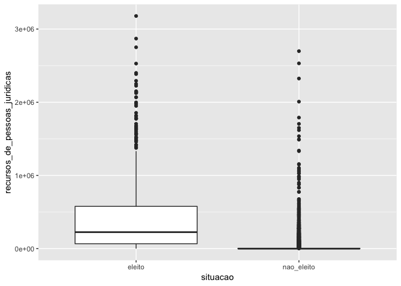

```r
train %>%
  ggplot(aes(situacao,
             recursos_de_pessoas_juridicas)) +
  geom_boxplot()
```

unbalanced in a range of values

### quantidade_doacoes

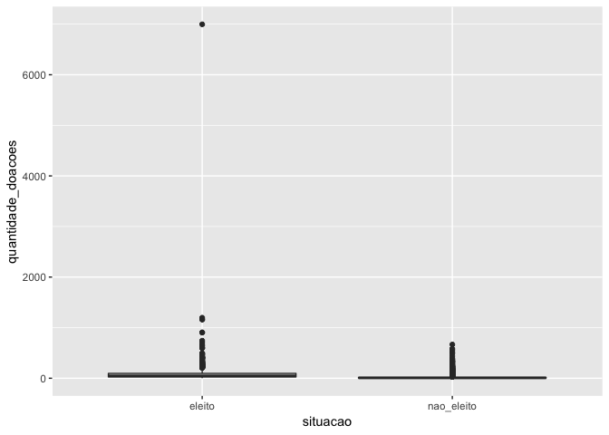

```r
train %>%
  ggplot(aes(situacao,
             quantidade_doacoes)) +
  geom_boxplot()
```

unbalanced to a very high amount of donations

### quantidade_doadores

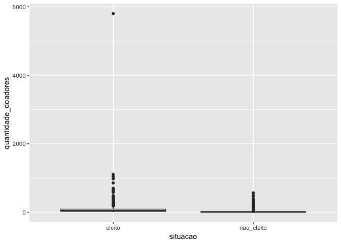

```r
train %>%
  ggplot(aes(situacao,
             quantidade_doadores)) +
  geom_boxplot()
```

the same situation of `quantidade_doacoes`

### media_receita

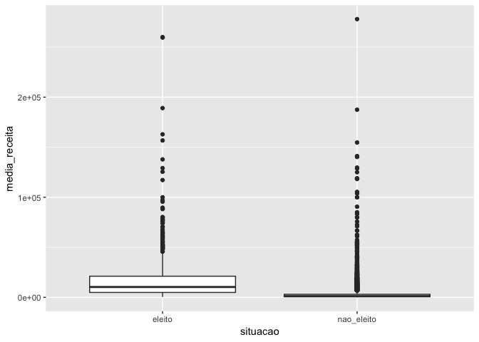

```r
train %>%
  ggplot(aes(situacao,
             media_receita)) +
  geom_boxplot()
```

cases of a very high value only for an unelected

### total_receita

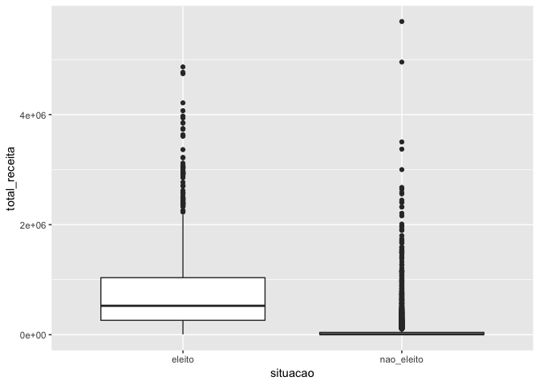

```r
train %>%
  ggplot(aes(situacao,
             total_receita)) +
  geom_boxplot()
```

ranges of values that are only present in non-elected

### sexo

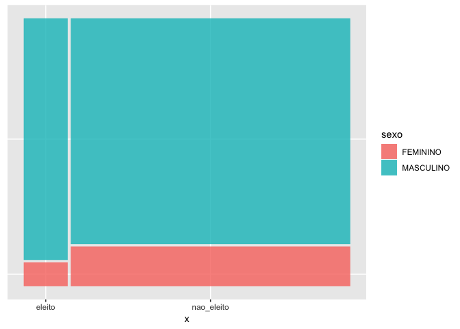

```r
train %>%
ggplot() +
   geom_mosaic(aes(x = product(sexo, situacao),
                   fill=sexo)) +
   theme(axis.title.y=element_blank(),
        axis.text.y=element_blank(),
        axis.ticks.y=element_blank())
```

### grau

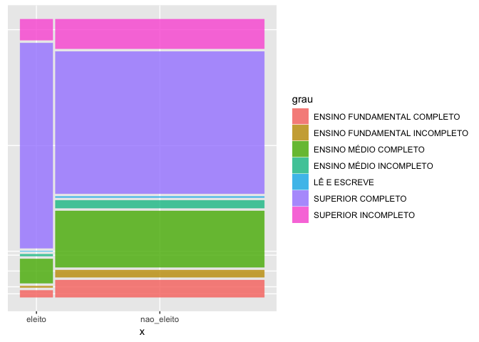

```r
train %>%
ggplot() +
   geom_mosaic(aes(x = product(grau, situacao),
                   fill=grau)) +
   theme(axis.title.y=element_blank(),
        axis.text.y=element_blank(),
        axis.ticks.y=element_blank())
```

### estado_civil

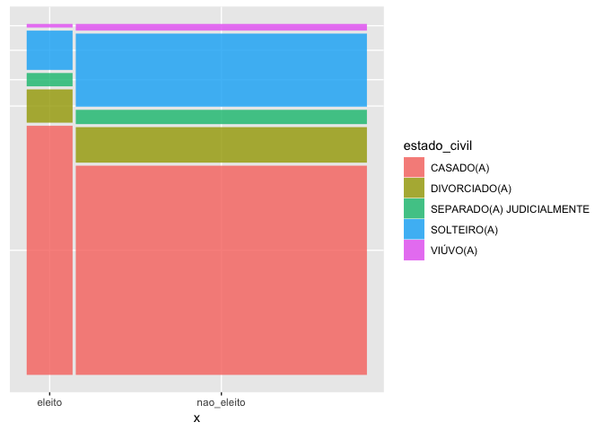

```r
train %>%
ggplot() +
   geom_mosaic(aes(x = product(estado_civil, situacao),
                   fill=estado_civil)) +
   theme(axis.title.y=element_blank(),
        axis.text.y=element_blank(),
        axis.ticks.y=element_blank())
```

> we can see that there is rather an imbalance in some variables, especially of values that are present only between elected or non-elected, this can cause problems of overfiting, and among the possible strategies for the correction of this problem will be used a hybrid in this study , undersampling more common values and resampling less common values.

The next step will build an encoding to transform `sexo` feature in a factor variable.

```r
encoding <- build_encoding(dataSet = train,
                           cols = c("sexo"),
                           verbose = F)

train <- one_hot_encoder(dataSet = train,
                           encoding = encoding,
                           drop = TRUE,
                           verbose = F)

encoding <- build_encoding(dataSet = validation,
                           cols = c("sexo"),
                           verbose = F)

validation <- one_hot_encoder(dataSet = validation,
                           encoding = encoding,
                           drop = TRUE,
                           verbose = F)

encoding <- build_encoding(dataSet = test,
                           cols = c("sexo"),
                           verbose = F)

test <- one_hot_encoder(dataSet = test,
                           encoding = encoding,
                           drop = TRUE,
                           verbose = F)
```

## Creating a personal function to evaluente F1 metric of a model.

```r
f1 <- function(data, lev = NULL, model = NULL) {
  f1_val <- F1_Score(y_pred = data$pred, y_true = data$obs, positive = lev[1])
  c(F1 = f1_val)
}

F_Measure <- function(expected, predicted, ...) {
  data.frame(expected=expected,
             prediction=predicted) %>%
      mutate(fn = ifelse(expected == "eleito" &
                         prediction == "nao_eleito",1,0),
             fp = ifelse(expected == "nao_eleito" &
                         prediction == "eleito",1,0)) -> result
}
```

## And we will remove all variables that has no or minimum variance beacuse them is uncessary for creating models.

```r
## Removing variables that was unnecessary or has a minim
train <- train %>% select(-nome,-ano, -ocupacao, -partido,
                          -estado_civil, -grau, -cargo,
                          -sequencial_candidato, -uf, -id)

validation <- validation %>% select(-nome,-ano, -ocupacao, -partido,
                          -estado_civil, -grau, -cargo,
                          -sequencial_candidato, -uf, -id)

test <- test %>% select(-nome,-ano, -ocupacao, -partido,
                          -estado_civil, -grau, -cargo, -uf)
```

> Finally, we can start to create the five models that we will test here, begining by decision three.

# Dessision Three

```r
set.seed(1)

cctrl <- trainControl(summaryFunction = f1, classProbs = TRUE, method = "boot", sampling = "smote")
lambda <- expand.grid(.cp = seq(from=0, to=0.02, by=0.005))

tree <- train(situacao ~ .,
              train,
              method="rpart",
              metric = "F1",
              tuneGrid = lambda,
              preProc = c("center", "scale"),
              trControl = trainControl(summaryFunction = f1, classProbs = TRUE, method = "boot"))
```

## Resultant model

```r
varImp(tree)
```

```
## rpart variable importance
##
##                                        Overall
## total_receita                         100.0000
## total_despesa                          99.6657
## recursos_de_pessoas_juridicas          87.2176
## quantidade_fornecedores                61.8274
## quantidade_despesas                    61.4545
## quantidade_doadores                     3.6181
## recursos_proprios                       2.8066
## media_despesa                           1.5733
## recursos_de_partido_politico            1.4601
## media_receita                           0.9026
## quantidade_doacoes                      0.8577
## recursos_de_pessoas_fisicas             0.6909
## sexo.MASCULINO                          0.0000
## recursos_de_outros_candidatos.comites   0.0000
## sexo.FEMININO                           0.0000
```

## and the best tunning for him

```r
tree$finalModel
```

```
## n= 6860
##
## node), split, n, loss, yval, (yprob)
##       * denotes terminal node
##
##  1) root 6860 931 nao_eleito (0.13571429 0.86428571)
##    2) total_receita>=0.06795873 1280 505 eleito (0.60546875 0.39453125)
##      4) recursos_de_pessoas_juridicas>=1.03738 472 103 eleito (0.78177966 0.21822034) *
##      5) recursos_de_pessoas_juridicas< 1.03738 808 402 eleito (0.50247525 0.49752475)
##       10) total_despesa>=0.6243804 310 123 eleito (0.60322581 0.39677419)
##         20) recursos_proprios< 3.169534 278 100 eleito (0.64028777 0.35971223) *
##         21) recursos_proprios>=3.169534 32   9 nao_eleito (0.28125000 0.71875000) *
##       11) total_despesa< 0.6243804 498 219 nao_eleito (0.43975904 0.56024096)
##         22) recursos_proprios>=-0.08563123 301 150 eleito (0.50166113 0.49833887)
##           44) quantidade_despesas< 0.3188294 202  91 eleito (0.54950495 0.45049505)
##             88) quantidade_doadores>=-0.0920028 158  62 eleito (0.60759494 0.39240506) *
##             89) quantidade_doadores< -0.0920028 44  15 nao_eleito (0.34090909 0.65909091) *
##           45) quantidade_despesas>=0.3188294 99  40 nao_eleito (0.40404040 0.59595960) *
##         23) recursos_proprios< -0.08563123 197  68 nao_eleito (0.34517766 0.65482234) *
##    3) total_receita< 0.06795873 5580 156 nao_eleito (0.02795699 0.97204301) *
```

## Let’s see the final three

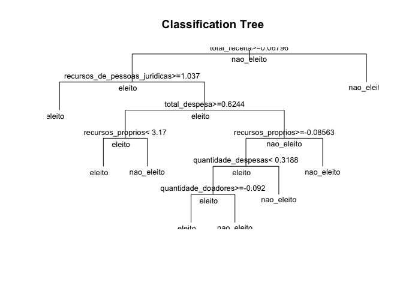

```r
# plot the model
plot(tree$finalModel, uniform=TRUE,
     main="Classification Tree")
text(tree$finalModel, all=TRUE, cex=.8)
```

## and the same but more pretty

[figure not shown]

```r
fancyRpartPlot(tree$finalModel)
```

## Model validation using false positive and false negative percentages of predictions

```r
data.frame(validation %>%
  select(-situacao) %>%
  predict(object=tree,.) %>%
  F_Measure(validation$situacao,.) %>%
  summarise(false_negative = sum(fn) / nrow(validation), false_positive = sum(fp) / nrow(validation)))
```

```
##   false_negative false_positive
## 1     0.03412073     0.04724409
```

## and now the F1 performance graph of this model for all hyper params tested

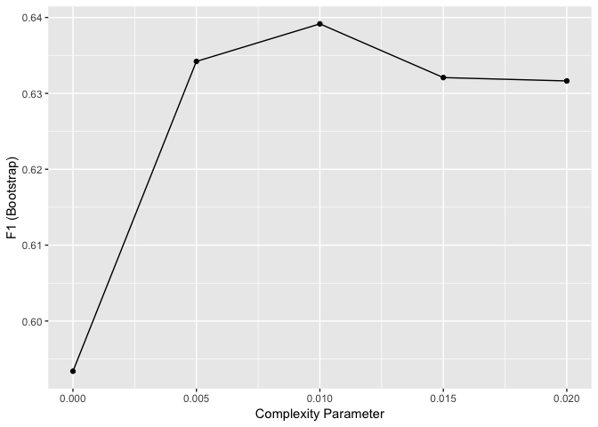

```r
ggplot(tree)
```

the F1 metric is medin to good, and the performance in validation predictions of false potives and false negatives together account for about 8%, for a medium F1 were good results

# Logistic regression

```r
set.seed(1)
rlGrid <- expand.grid( cost = c(200,2,0.02),
                       loss = c("L2_dual"),
                       epsilon = c(0.001, 0.01) )

cctrl2 <- trainControl(summaryFunction = f1, classProbs = TRUE, method = "cv", number = 5, sampling = "smote")

logistic <- train(situacao ~ ., train,
                             method = "regLogistic",
                             trControl = cctrl2,
                             metric = "F1",
                             preProc = c("center", "scale"),
                             tuneGrid = rlGrid)
```

## Resultant model

```r
varImp(logistic)
```

```
## ROC curve variable importance
##
##                                       Importance
## total_despesa                             100.00
## total_receita                              99.96
## quantidade_fornecedores                    90.21
## quantidade_despesas                        90.01
## recursos_de_pessoas_juridicas              89.79
## quantidade_doacoes                         85.81
## quantidade_doadores                        85.59
## media_receita                              82.48
## recursos_de_pessoas_fisicas                80.05
## media_despesa                              64.85
## recursos_proprios                          52.92
## recursos_de_outros_candidatos.comites      39.83
## recursos_de_partido_politico               32.78
## sexo.FEMININO                               0.00
## sexo.MASCULINO                              0.00
```

## and the best tunning for him

```r
logistic$finalModel
```

```
## $TypeDetail
## [1] "L2-regularized logistic regression dual (L2R_LR_DUAL)"
##
## $Type
## [1] 7
##
## $W
##      quantidade_doacoes quantidade_doadores total_receita media_receita
## [1,]         0.06761115            -1.51121    -0.3568663    -0.6368428
##      recursos_de_outros_candidatos.comites recursos_de_pessoas_fisicas
## [1,]                             0.0215394                  -0.8941101
##      recursos_de_pessoas_juridicas recursos_proprios
## [1,]                    -0.6634031        -0.1554319
##      recursos_de_partido_politico quantidade_despesas
## [1,]                    0.6104716            1.200539
##      quantidade_fornecedores total_despesa media_despesa sexo.FEMININO
## [1,]             -0.02511319       -2.6219    -0.4423231    0.01841145
##      sexo.MASCULINO       Bias
## [1,]    -0.01841145 -0.4740965
##
## $Bias
## [1] 1
##
## $ClassNames
## [1] nao_eleito eleito
## Levels: eleito nao_eleito
##
## $NbClass
## [1] 2
##
## $xNames
##  [1] "quantidade_doacoes"
##  [2] "quantidade_doadores"
##  [3] "total_receita"
##  [4] "media_receita"
##  [5] "recursos_de_outros_candidatos.comites"
##  [6] "recursos_de_pessoas_fisicas"
##  [7] "recursos_de_pessoas_juridicas"
##  [8] "recursos_proprios"
##  [9] "recursos_de_partido_politico"
```

[output cut: 9 more lines]

```
##
## $tuneValue
##   cost    loss epsilon
## 3    2 L2_dual   0.001
##
## $obsLevels
## [1] "eleito"     "nao_eleito"
## attr(,"ordered")
## [1] FALSE
##
## $param
## list()
##
## attr(,"class")
## [1] "LiblineaR"
```

## Model validation using false positive and false negative percentages of predictions

```r
data.frame(validation %>%
  select(-situacao) %>%
  predict(object=logistic,.) %>%
  F_Measure(validation$situacao,.) %>%
  summarise(false_negative = sum(fn) / nrow(validation), false_positive = sum(fp) / nrow(validation)))
```

```
##   false_negative false_positive
## 1     0.02099738     0.06299213
```

## and now the F1 performance graph of this model for all hyper params tested

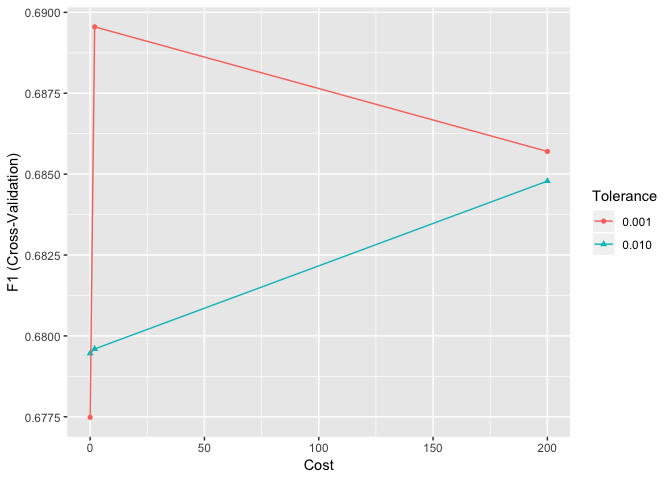

```r
ggplot(logistic)
```

# KNN

```r
set.seed(1)
neighborsGrid <- expand.grid(.k = seq(from=1, to=50, by=1))

knn <- train(situacao ~ ., train,
        metric = "F1",
        method = "knn",
        tuneGrid = neighborsGrid,
        trControl = cctrl2)
```

## Resultant model

```r
varImp(knn)
```

```
## ROC curve variable importance
##
##                                       Importance
## total_despesa                             100.00
## total_receita                              99.96
## quantidade_fornecedores                    90.21
## quantidade_despesas                        90.01
## recursos_de_pessoas_juridicas              89.79
## quantidade_doacoes                         85.81
## quantidade_doadores                        85.59
## media_receita                              82.48
## recursos_de_pessoas_fisicas                80.05
## media_despesa                              64.85
## recursos_proprios                          52.92
## recursos_de_outros_candidatos.comites      39.83
## recursos_de_partido_politico               32.78
## sexo.FEMININO                               0.00
## sexo.MASCULINO                              0.00
```

## and the best tunning for him

```r
knn$bestTune
```

```
##     k
## 35 35
```

## Model validation using false positive and false negative percentages of predictions

```r
data.frame(validation %>%
  select(-situacao) %>%
  predict(object=knn,.) %>%
  F_Measure(validation$situacao,.) %>%
  summarise(false_negative = sum(fn) / nrow(validation), false_positive = sum(fp) / nrow(validation)))
```

```
##   false_negative false_positive
## 1    0.005249344      0.1102362
```

## and now the F1 performance graph of this model for all hyper params tested

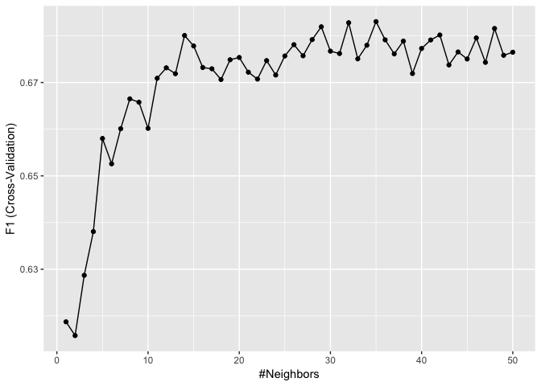

```r
ggplot(knn)
```

# AdaBoost

```r
set.seed(1)
grid <- expand.grid(mfinal = (1:3)*3, maxdepth = c(1, 2),
                    coeflearn = c("Breiman", "Freund", "Zhu"))

seeds <- vector(mode = "list", length = nrow(train) + 1)
seeds <- lapply(seeds, function(x) 1:20)

cctrl2 <- trainControl(summaryFunction = f1, classProbs = TRUE, method = "cv", number = 5)
adaboost <- train(situacao ~ ., train,
                             method = "AdaBoost.M1",
                             trControl = cctrl,
                            na.action = na.exclude,
                             tuneGrid = grid,
                             metric = "F1",
                             preProc = c("center", "scale"))
```

## Resultant model

```r
varImp(adaboost)
```

```
## AdaBoost.M1 variable importance
##
##                                        Overall
## total_receita                         100.0000
## total_despesa                          24.3953
## recursos_de_pessoas_juridicas           4.3038
## recursos_proprios                       4.1647
## media_despesa                           1.4067
## recursos_de_pessoas_fisicas             0.3218
## quantidade_doadores                     0.0000
## quantidade_fornecedores                 0.0000
## quantidade_doacoes                      0.0000
## sexo.FEMININO                           0.0000
## recursos_de_partido_politico            0.0000
## recursos_de_outros_candidatos.comites   0.0000
## quantidade_despesas                     0.0000
## media_receita                           0.0000
## sexo.MASCULINO                          0.0000
```

## Model validation using false positive and false negative percentages of predictions

```r
data.frame(validation %>%
  select(-situacao) %>%
  predict(object=adaboost,.) %>%
  F_Measure(validation$situacao,.) %>%
  summarise(false_negative = sum(fn) / nrow(validation), false_positive = sum(fp) / nrow(validation)))
```

```
##   false_negative false_positive
## 1    0.002624672      0.1154856
```

## and now the F1 performance graph of this model for all hyper params tested

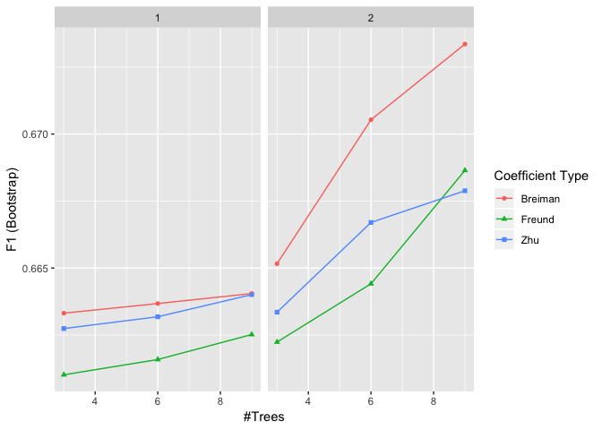

```r
ggplot(adaboost)
```

the F1 metric is median, with a courious results of validation, a minimal percentage of false negatives and more than 11% of false positives.

> In all models, and shown more explicitly in the decision tree, parameters for spending money in the field seem to be the most important, and show what really makes a difference for a candidate to be elected or not.

## Following, we will test and big famous model, the gradient boosting, as a extra model.

```r
seeds <- vector(mode = "list", length = nrow(train) + 1)
seeds <- lapply(seeds, function(x) 1:20)

cctrl3 <- trainControl(
  summaryFunction = f1,
  classProbs = TRUE,
  method = "cv",
  number = 10,
  seeds = seeds)

gbm <- train(situacao ~ ., train,
                             method = "gbm",
                             trControl = cctrl3,
                             metric = "F1",
             na.action = na.exclude,
                             preProc = c("center", "scale"),
                             tuneGrid = expand.grid(interaction.depth = c(1, 2, 3, 4, 5),
                                       shrinkage = c(.12, .13),
                                       n.trees = c(55, 56, 57, 58, 59),
                                       n.minobsinnode = c(2,3)),
                             verbose = FALSE,
                            distribution = "adaboost")
```

## the best tunning for him

```r
gbm$bestTune
```

```
##   n.trees interaction.depth shrinkage n.minobsinnode
## 6      55                 1      0.12              3
```

## Model validation using false positive and false negative percentages of predictions

```r
data.frame(validation %>%
  select(-situacao) %>%
  predict(object=gbm,.) %>%
  F_Measure(validation$situacao,.) %>%
  summarise(false_negative = sum(fn) / nrow(validation), false_positive = sum(fp) / nrow(validation)))
```

```
##   false_negative false_positive
## 1      0.0328084     0.04593176
```

## and now the F1 performance graph of this model for all hyper params tested

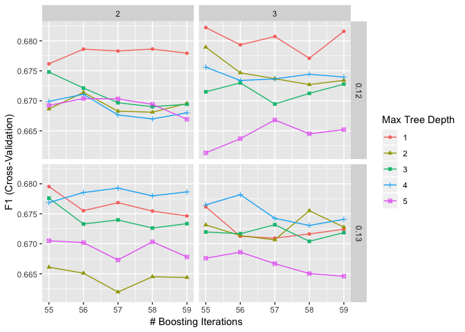

```r
ggplot(gbm)
```

## Results

The results of this study show that the models achieve a reasonable performance for metric F1, being the gradient boosting model the chosen one for the sending to competition of the Kaggle, we also saw that in the general, variables referring to financial investment and support of companies were the features that in all models showed to have the greatest relevance

> Generation predictions for test dataframe to submit to Kaggle, to related [competition](https://www.kaggle.com/c/ufcg-cdp-20182).

```r
prediction <- predict(gbm, test)
data_out <- data.frame(ID = test$sequencial_candidato, Predicted = prediction)
data_out$ID <-as.character(data_out$ID)
data_out %>% write_csv(path = "response.csv")
```